# Урок 3

[figure not shown]

### 1 Цикл while

### 2 Списки

### 3 Цикл for

### 4 Мини-практикум

Циклы используются в тех случаях, когда нужно повторить блок кода определенное количество раз.

## Цикл while

Программисты не любят повторяться. Программирование — это автоматизация вещей, поэтому мы не хотим приветствовать каждого человека по имени вручную, верно? Здесь пригодятся циклы.

Цикл while используется в Python для неоднократного исполнения определенной инструкции до тех пор, пока заданное условие остается истинным. Этот цикл позволяет программе перебирать блок кода.

```python
a = 1

while a < 10:
    print('Цикл выполнился', a, 'раз(а)')
    a = a+1
print('Цикл окончен')
```

```
Цикл выполнился 1 раз(а)
Цикл выполнился 2 раз(а)
Цикл выполнился 3 раз(а)
Цикл выполнился 4 раз(а)
Цикл выполнился 5 раз(а)
Цикл выполнился 6 раз(а)
Цикл выполнился 7 раз(а)
Цикл выполнился 8 раз(а)
Цикл выполнился 9 раз(а)
Цикл окончен
```

[figure not shown]

```python
a = 1

while a==1:
    b = input('Как тебя зовут?')
    print('Привет', b, ', Добро пожаловать')
```

```python
a=2
```

```python
a = 5
while a > 0:
    print(a)
    a -= 1
```

```
5
4
3
2
1
```

Вывести все нечетные числа от 5 до 55

```python
a = 5
while a <= 55:
    if a % 2 == 1:
        print(a, end=' ')
    a += 1
```

[output not shown]

```python
print(1, 2, 3)
print(4, 5, 6)
print(1, 2, 3, sep=', ', end='. ')
print(4, 5, 6, sep=', ', end='. ')
print()
print(1, 2, 3, sep='', end=' -- ')
print(4, 5, 6, sep=' * ', end='.')
```

```
1 2 3
4 5 6
1, 2, 3. 4, 5, 6.
123 -- 4 * 5 * 6.
```

```python
a = 1

while a < 5:
   print('условие верно')
   a = a + 1
else:
   print('условие неверно')
```

```
условие верно
условие верно
условие верно
условие верно
условие неверно
```

Посчитать сумму чисел от a до b

```python
a = int(input())
b = int(input())
s = 0
i = a
while i <= b:
    s += i
    i += 1
print(s)
```

```
4
10
49
```

Вывести произведение пяти пар чисел

```python
i = 0
while i < 5:
    a, b = input().split()  # split() разбивает строку на части по пробелам
    a = int(a)
    b = int(b)
    print(a * b)
    i += 1
```

```
12
```

[output not shown]

### Методы и функции строк

```python
s='Привет Мисис'
```

```python
s2='123'
```

```python
len(s)
```

```
12
```

```python
s.upper()
```

```
'ПРИВЕТ МИСИС'
```

```python
s.lower()
```

```
'привет мисис'
```

```python
s.count('с')
```

```
2
```

```python
s.isalnum()
```

```
False
```

```python
s.find('c')
```

```
-1
```

```python
s.replace('с', 'f')
```

```
'Привет Миfиf'
```

https://pythonworld.ru/tipy-dannyx-v-python/stroki-funkcii-i-metody-strok.html

## Операторы break, continue

Break — ключевое слово break прерывает цикл и передает управление в конец цикла

```python
i = 0
while i < 5:
    a, b = input().split()
    a = int(a)
    b = int(b)
    if (a == 0) and (b == 0):
        break # досрочно завершаем цикл
    print(a * b)
    i += 1
```

Continue — ключевое слово continue прерывает текущую итерацию и передает управление в начало цикла, после чего условие снова проверяется. Если оно истинно, исполняется следующая итерация.

```python
i = 0
while i < 5:
    a, b = input().split()
    a = int(a)
    b = int(b)
    if (a == 0) and (b == 0):
        break # досрочно завершаем цикл
    if (a == 0) or (b == 0):
        continue # переходим к следующей итерации
    print(a * b)
    i += 1
```

```
0 6
23 23
529
```

```python
%time
print('ddfgdf'*100000)
```

```
CPU times: user 0 ns, sys: 0 ns, total: 0 ns
Wall time: 8.11 µs
ddfgdfddfgdfddfgdfddfgdfddfgdfddfgdfddfgdfddfgdfddfgdfddfgdf…
```

[output not shown]

## Цикл for

Цикл for, также называемый циклом с параметром, в языке Питон богат возможностями. В цикле for указывается переменная и множество значений, по которому будет пробегать переменная. Множество значений может быть задано списком, кортежем, строкой или диапазоном.

```python
for i in 2, 3, 5:
    print(i * i)
```

```
4
9
25
```

```python
for color in 'red', 'orange', 'yellow', 'green', 'cyan', 'blue', 'violet':
    print('#',  ' color of rainbow is ', color, sep = '')
```

```
# color of rainbow is red
# color of rainbow is orange
# color of rainbow is yellow
# color of rainbow is green
# color of rainbow is cyan
# color of rainbow is blue
# color of rainbow is violet
```

```python
for i in 1, 2, 3, 'one', 'two', 'three':
    print(i)
```

```
1
2
3
one
two
three
```

Как правило, циклы for используются либо для повторения какой-либо последовательности действий заданное число раз, либо для изменения значения переменной в цикле от некоторого начального значения до некоторого конечного.

Для повторения цикла некоторое заданное число раз n можно использовать цикл for вместе с функцией range:

```python
for i in range(4):  # равносильно инструкции for i in 0, 1, 2, 3:
    # здесь можно выполнять циклические действия
    print(i)
    print(i ** 2)
# цикл закончился, поскольку закончился блок с отступом
print('Конец цикла')
```

```
0
0
1
1
2
4
3
9
Конец цикла
```

```python
for i in range(10):
    print(i * i)
```

```python
n = int(input())
for i in range(n):
    print('*' * n)
```

```
10
**********
**********
**********
**********
**********
**********
**********
**********
**********
**********
```

Сумма нечетных чисел на отрезке от a до b

```python
a, b = input().split()
a = int(a)
b = int(b)
s = 0
for i in range(a, b + 1):
    if i % 2 == 1:
        s += i
print(s)
```

```
-10 -5
-21
```

```python
for i in range(0):
    print(i)
```

Наконец, чтобы организовать цикл, в котором индексная переменная будет уменьшаться, необходимо использовать функцию range с тремя параметрами. Первый параметр задает начальное значение индексной переменной, второй параметр — значение, до которого будет изменяться индексная переменная (не включая его!), а третий параметр — величину изменения индексной переменной. Например, сделать цикл по всем нечетным числам от 1 до 99 можно при помощи функции range(1, 100, 2), а сделать цикл по всем числам от 100 до 1 можно при помощи range(100, 0, -1).

Подсчет числа символов C в строке

```python
genome = input()
cnt = 0
for nucl in genome:
    if nucl == 'C':
        cnt += 1
print(cnt)
```

```
qwerCCCccc
3
```

https://pythonworld.ru/tipy-dannyx-v-python/stroki-funkcii-i-metody-strok.html

## Срезы (slices)

Срез (slice) — извлечение из данной строки одного символа или некоторого фрагмента (подстроки). Есть три формы срезов. Самая простая форма среза: взятие одного символа строки, а именно, S[i] — это срез, состоящий из одного символа, который имеет номер i, при этом считая, что нумерация начинается с числа 0. То есть если S = ‘Hello’, то S[0]=='H', S[1]=='e', S[2]=='l', S[3]=='l', S[4]=='o'.

Номера символов в строке (а также в других структурах данных: списках, кортежах) называются индексом.

Если указать отрицательное значение индекса, то номер будет отсчитываться с конца, начиная с номера -1. То есть

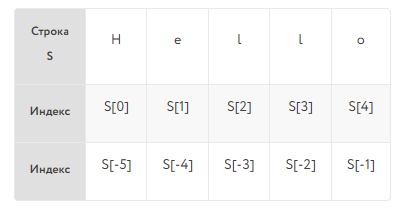

```python
s = 'ATTCGGAGCT'
```

```python
s[1]
```

```
'T'
```

```python
s[1:4]
```

```
'TTC'
```

```python
s[4:]
```

```
'GGAGCT'
```

```python
s[1:-1]
```

```
'TTCGGAGC'
```

```python
s[1:-1:2]
```

```
'TCGG'
```

```python
s[::-1]
```

```
'TCGAGGCTTA'
```

###### Палидром

```python
s = input()
r = s[::-1]
if s == r:
    print('YES')
else:
    print('NO')
```

```
qwewrert
NO
```

https://foxford.ru/wiki/informatika/srezy-strok-v-python